# Juvenile Snowshow Hare Exploratory Report

Logan Babcock

November 4, 2021

## 1. Overview

This is an exploratory report on juvenile snoeshoe hares (*Lepus americanus*) using data collected during the US Long Term Ecological Research Network's study on Snowshoe hare physical data in the Bonanza Creek Experimental Forest. Using the data collected from 1999-2012, this report will analyze the counts and sizes of juvenile hares. This report will also compare the weights of juvenile hares according to sex, and perform a simple linear analysis on the relationship between hind foot length and body mass.

## 2. Data and Methods

Snowshoe hare data and measurements were made accessible through Knut Kielland and associates at the Bonanza Creek LTER. The data contain measurements and observations on hares during a capture-recapture study done in Alaska's Tanana valley from 1999-2012. Following exploratory data visualization, body mass measurements between male and female juvenile showshoe hares are compared using a two-sample t-test using a significance level (α) of 0.05 throughout. Differences between groups are described by a Cohen's d effect size. The relationship between body mass and hind foot length is explored by simple linear regression. All analysis are in R version 3.6.3 and R Studio Version 1.1.463

## Data Visualization and Analysis

### Juvenile Hare Survey Counts

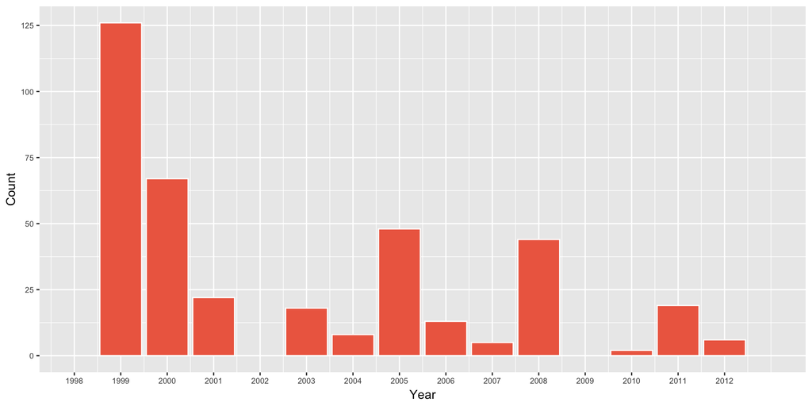

**Figure 1:** Number of juvenile hares caught during sampling from 1998-2012 at Bonanza LTE.

### Juvenile Hare Weights

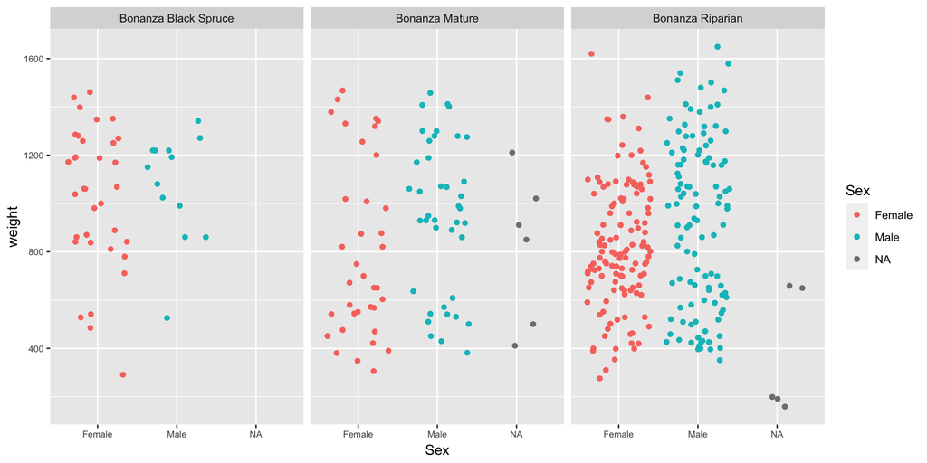

**Figure 2:** This plot shows the distribution of hare weights (g) for each sex, and categorized by survey site.

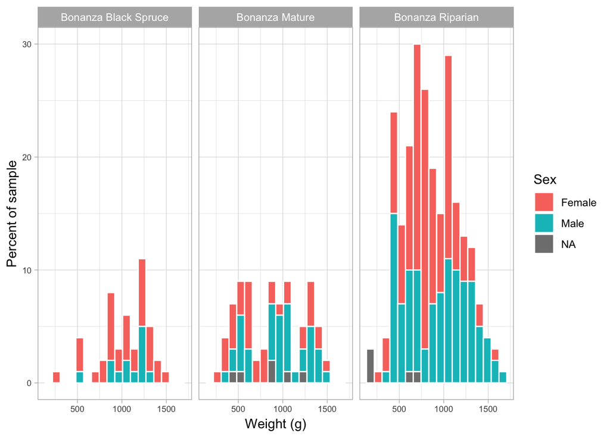

Figure 2 and Figure 3 above show the comparison between female and male juvenile showshoe hare weights first in a jitter plot and then in a side by side histograms. Samples taken where sex was not recorded are represented by 'NA'. In the jitter plot, the hares are separated by the site they were caught at, and it is clear that the least number of hares caught was at the Bonanza Black Spruce site, and the most at the Bonanza Riparian site. At the Ripairian site, the female observations are more concentrated, and the male observations are more spread out. This is shown further in the histogram, where the distribution of female weights adhere to a curve with a peak, and the male weights have a larger spread with less of a notable peak. The weights do not vary largely between the sexes, or between site location. On average at each of the site, female and male juvenile hares have similar weight distributions.

### Juvenile Hare Weights Comparison

**Table 2:** Summary Statistics for Female and Male Juvenile Hare Weights

| Sex | Mean | Standard Deviation | Median Size (g) | Count |
| --- | --- | --- | --- | --- |
| f | 855.39 | 292.25 | 825 | 197 |
| m | 945.86 | 333.22 | 990 | 163 |

Getting a p-value of 0.0070933 means that there is a 0.7% chance of getting means that are at least as different as those seen here if they're drawn from populations with the same mean. This means that we would reject the null hypothesis that the population's mean weights are the same.

### Juvenile Weight & Hind Foot Length

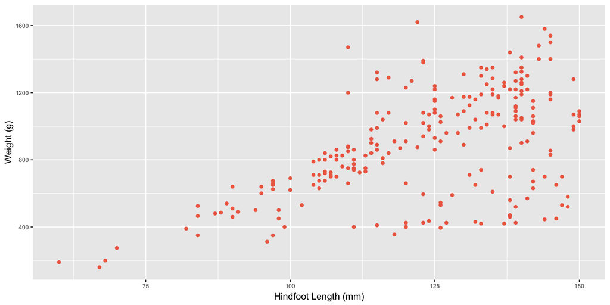

**Figure 4:** Hindfoot lenth (mm) and hare weight (g) are plotted to visualize their relationship.

Simple linear regression was used to explore the relationship between juvenile snowshoe hare hindfoot lenth (mm) and body weight (g) across all three sampling sites, including both male and female hares. A regression model was found ($\beta$ = 9.523, F(1,247) = 105.2, p < 0.001) with an R<sup>2</sup> of 0.299.

With this linear regression, the R<sup>2</sup> value of 0.2987695 means that only 29.8769547% of the variance is in body mass is predictable from the change in hindfoot length.

Using a Pearson's R correlation, we see that there is a *moderatley strong* correlation between juvenile hare hind foot length and body weight (*r* = 0.55, t(247) = 10.26, p < 0.001).

## Next Steps

- Adding more predictor variables to the linear analysis, such as sex or site may reveal other predictors on juvenile hare weight
- Investigating if the relationship between hind foot length and body mass is continued in adult snowshoe hares

### Data Citation

Kielland, K., F.S. Chapin, R.W. Ruess, and Bonanza Creek LTER. 2017. Snowshoe hare physical data in Bonanza Creek Experimental Forest: 1999-Present ver 22. Environmental Data Initiative. https://doi.org/10.6073/pasta/03dce4856d79b91557d8e6ce2cbcdc14